# **Project: Analyzing the `Medical Appointment No Shows` Kaggle Dataset**

### by **Mário Damhur**

- Introduction
- Data Wrangling
- Exploratory Data Analysis
- Conclusions

## **Introduction**

A person makes a doctor appointment, receives all the instructions and no-show. Who to blame?

This dataset collects information from 100k medical appointments in Brazil and is focused on the question of whether or not patients show up for their appointment. A number of characteristics about the patient are included in each row.

## **Dataset**

110.527 medical appointments its 14 associated variables (characteristics). The most important one if the patient show-up or no-show to the appointment. Variable names are self-explanatory.

- **PatientId**: Identification of a patient
- **AppointmentID**: Identification of each appointment
- **Gender**: Male or Female.
- **DataMarcacaoConsulta**: The day of the actuall appointment, when they have to visit the doctor.
- **DataAgendamento**: The day someone called or registered the appointment, this is before appointment of course.
- **Age**: How old is the patient.
- **Neighbourhood**: Where the appointment takes place.
- **Scholarship**: True of False . Observation, this is a broad topic, consider reading this article https://en.wikipedia.org/wiki/Bolsa_Fam%C3%ADlia
- **Hipertension**: True or False
- **Diabetes**: True or False
- **Alcoholism**: True or False
- **Handcap**: Number of handicaps this person have [0,1,2,3,4]
- **SMS_received**: True or False.
- **No-show**: True or False.

## **Imports**

```python
import pandas as pd
import numpy as np
import seaborn as sb
import requests
import kaggle
import os
import matplotlib.pyplot as plt
%matplotlib inline


# Set parameters
#pd.options.display.float_format = '{:3,}'.format

plt.rcParams["figure.figsize"] = (9, 6)

SMALL_SIZE = 13
MEDIUM_SIZE = 15
BIGGER_SIZE = 18

plt.rc('font', size=SMALL_SIZE)          # controls default text sizes
plt.rc('axes', titlesize=BIGGER_SIZE)     # fontsize of the axes title
plt.rc('axes', labelsize=MEDIUM_SIZE)    # fontsize of the x and y labels
plt.rc('xtick', labelsize=SMALL_SIZE)    # fontsize of the tick labels
plt.rc('ytick', labelsize=SMALL_SIZE)    # fontsize of the tick labels
plt.rc('legend', fontsize=SMALL_SIZE)    # legend fontsize
```

## **Data Wrangling**

### **Gather**

```python
# Download the dataset with Kaggle API
directory = 'data'

if not os.path.exists(directory):
    os.makedirs(directory)

# Need Kaggle API https://github.com/Kaggle/kaggle-api
kaggle.api.authenticate()
kaggle.api.dataset_download_files('joniarroba/noshowappointments', path=directory, unzip=True)
```

### **Assess**

#### **Visual Assessment**

```python
brazil_df = pd.read_csv(directory + '/KaggleV2-May-2016.csv')
brazil_df
```

|  | PatientId | AppointmentID | Gender | ScheduledDay | AppointmentDay | Age | Neighbourhood | Scholarship | Hipertension | Diabetes | Alcoholism | Handcap | SMS_received | No-show |
| --- | --- | --- | --- | --- | --- | --- | --- | --- | --- | --- | --- | --- | --- | --- |
| 0 | 2.987250e+13 | 5642903 | F | 2016-04-29T18:38:08Z | 2016-04-29T00:00:00Z | 62 | JARDIM DA PENHA | 0 | 1 | 0 | 0 | 0 | 0 | No |
| 1 | 5.589978e+14 | 5642503 | M | 2016-04-29T16:08:27Z | 2016-04-29T00:00:00Z | 56 | JARDIM DA PENHA | 0 | 0 | 0 | 0 | 0 | 0 | No |
| 2 | 4.262962e+12 | 5642549 | F | 2016-04-29T16:19:04Z | 2016-04-29T00:00:00Z | 62 | MATA DA PRAIA | 0 | 0 | 0 | 0 | 0 | 0 | No |
| 3 | 8.679512e+11 | 5642828 | F | 2016-04-29T17:29:31Z | 2016-04-29T00:00:00Z | 8 | PONTAL DE CAMBURI | 0 | 0 | 0 | 0 | 0 | 0 | No |
| 4 | 8.841186e+12 | 5642494 | F | 2016-04-29T16:07:23Z | 2016-04-29T00:00:00Z | 56 | JARDIM DA PENHA | 0 | 1 | 1 | 0 | 0 | 0 | No |
| ... | ... | ... | ... | ... | ... | ... | ... | ... | ... | ... | ... | ... | ... | ... |
| 110522 | 2.572134e+12 | 5651768 | F | 2016-05-03T09:15:35Z | 2016-06-07T00:00:00Z | 56 | MARIA ORTIZ | 0 | 0 | 0 | 0 | 0 | 1 | No |
| 110523 | 3.596266e+12 | 5650093 | F | 2016-05-03T07:27:33Z | 2016-06-07T00:00:00Z | 51 | MARIA ORTIZ | 0 | 0 | 0 | 0 | 0 | 1 | No |
| 110524 | 1.557663e+13 | 5630692 | F | 2016-04-27T16:03:52Z | 2016-06-07T00:00:00Z | 21 | MARIA ORTIZ | 0 | 0 | 0 | 0 | 0 | 1 | No |
| 110525 | 9.213493e+13 | 5630323 | F | 2016-04-27T15:09:23Z | 2016-06-07T00:00:00Z | 38 | MARIA ORTIZ | 0 | 0 | 0 | 0 | 0 | 1 | No |
| 110526 | 3.775115e+14 | 5629448 | F | 2016-04-27T13:30:56Z | 2016-06-07T00:00:00Z | 54 | MARIA ORTIZ | 0 | 0 | 0 | 0 | 0 | 1 | No |

110527 rows × 14 columns

#### **Programmatic Assessment**

```python
brazil_df.info()
```

```
<class 'pandas.core.frame.DataFrame'>
RangeIndex: 110527 entries, 0 to 110526
Data columns (total 14 columns):
 #   Column          Non-Null Count   Dtype
---  ------          --------------   -----
 0   PatientId       110527 non-null  float64
 1   AppointmentID   110527 non-null  int64
 2   Gender          110527 non-null  object
 3   ScheduledDay    110527 non-null  object
 4   AppointmentDay  110527 non-null  object
 5   Age             110527 non-null  int64
 6   Neighbourhood   110527 non-null  object
 7   Scholarship     110527 non-null  int64
 8   Hipertension    110527 non-null  int64
 9   Diabetes        110527 non-null  int64
 10  Alcoholism      110527 non-null  int64
 11  Handcap         110527 non-null  int64
 12  SMS_received    110527 non-null  int64
 13  No-show         110527 non-null  object
dtypes: float64(1), int64(8), object(5)
memory usage: 11.8+ MB
```

```python
brazil_df.duplicated().sum()
```

```
0
```

```python
brazil_df.describe().round().T
```

|  | count | mean | std | min | 25% | 50% | 75% | max |
| --- | --- | --- | --- | --- | --- | --- | --- | --- |
| PatientId | 110527.0 | 1.474963e+14 | 2.560949e+14 | 39218.0 | 4.172614e+12 | 3.173184e+13 | 9.439172e+13 | 9.999816e+14 |
| AppointmentID | 110527.0 | 5.675305e+06 | 7.129600e+04 | 5030230.0 | 5.640286e+06 | 5.680573e+06 | 5.725524e+06 | 5.790484e+06 |
| Age | 110527.0 | 3.700000e+01 | 2.300000e+01 | -1.0 | 1.800000e+01 | 3.700000e+01 | 5.500000e+01 | 1.150000e+02 |
| Scholarship | 110527.0 | 0.000000e+00 | 0.000000e+00 | 0.0 | 0.000000e+00 | 0.000000e+00 | 0.000000e+00 | 1.000000e+00 |
| Hipertension | 110527.0 | 0.000000e+00 | 0.000000e+00 | 0.0 | 0.000000e+00 | 0.000000e+00 | 0.000000e+00 | 1.000000e+00 |
| Diabetes | 110527.0 | 0.000000e+00 | 0.000000e+00 | 0.0 | 0.000000e+00 | 0.000000e+00 | 0.000000e+00 | 1.000000e+00 |
| Alcoholism | 110527.0 | 0.000000e+00 | 0.000000e+00 | 0.0 | 0.000000e+00 | 0.000000e+00 | 0.000000e+00 | 1.000000e+00 |
| Handcap | 110527.0 | 0.000000e+00 | 0.000000e+00 | 0.0 | 0.000000e+00 | 0.000000e+00 | 0.000000e+00 | 4.000000e+00 |
| SMS_received | 110527.0 | 0.000000e+00 | 0.000000e+00 | 0.0 | 0.000000e+00 | 0.000000e+00 | 1.000000e+00 | 1.000000e+00 |

```python
print('Unique values in Gender:', brazil_df.Gender.unique())
print('Unique values in Scholarship:', brazil_df.Scholarship.unique())
print('Unique values in Hipertension:', brazil_df.Hipertension.unique())
print('Unique values in Diabetes:', brazil_df.Diabetes.unique())
print('Unique values in Alcoholism:', brazil_df.Alcoholism.unique())
print('Unique values in Handcap:', brazil_df.Handcap.unique())
print('Unique values in SMS_received:', brazil_df.SMS_received.unique())
print('Unique values in No-show:', brazil_df['No-show'].unique())
```

```
Unique values in Gender: ['F' 'M']
Unique values in Scholarship: [0 1]
Unique values in Hipertension: [1 0]
Unique values in Diabetes: [0 1]
Unique values in Alcoholism: [0 1]
Unique values in Handcap: [0 1 2 3 4]
Unique values in SMS_received: [0 1]
Unique values in No-show: ['No' 'Yes']
```

```python
print(sorted(brazil_df.Age.unique()))
```

[output not shown]

```python
print('Values "-1" in Age column:', brazil_df[brazil_df.Age == -1].shape[0])
print('Values "0" in Age column:', brazil_df[brazil_df.Age == 0].shape[0])
```

```
Values "-1" in Age column: 1
Values "0" in Age column: 3539
```

- Values with 0 maybe are babies with few months of Age. We can check this hypothesis from others feeatures

```python
brazil_df.query('(Age == 0) & (Hipertension == 1 | Diabetes == 1 | Alcoholism == 1)').shape[0]
```

```
0
```

- The results suggested that values of 0 are the babies with few months of age.

```python
brazil_df.Neighbourhood.unique()
```

```
array(['JARDIM DA PENHA', 'MATA DA PRAIA', 'PONTAL DE CAMBURI',
       'REPÚBLICA', 'GOIABEIRAS', 'ANDORINHAS', 'CONQUISTA',
       'NOVA PALESTINA', 'DA PENHA', 'TABUAZEIRO', 'BENTO FERREIRA',
       'SÃO PEDRO', 'SANTA MARTHA', 'SÃO CRISTÓVÃO', 'MARUÍPE',
       'GRANDE VITÓRIA', 'SÃO BENEDITO', 'ILHA DAS CAIEIRAS',
       'SANTO ANDRÉ', 'SOLON BORGES', 'BONFIM', 'JARDIM CAMBURI',
       'MARIA ORTIZ', 'JABOUR', 'ANTÔNIO HONÓRIO', 'RESISTÊNCIA',
       'ILHA DE SANTA MARIA', 'JUCUTUQUARA', 'MONTE BELO',
       'MÁRIO CYPRESTE', 'SANTO ANTÔNIO', 'BELA VISTA', 'PRAIA DO SUÁ',
       'SANTA HELENA', 'ITARARÉ', 'INHANGUETÁ', 'UNIVERSITÁRIO',
       'SÃO JOSÉ', 'REDENÇÃO', 'SANTA CLARA', 'CENTRO', 'PARQUE MOSCOSO',
       'DO MOSCOSO', 'SANTOS DUMONT', 'CARATOÍRA', 'ARIOVALDO FAVALESSA',
       'ILHA DO FRADE', 'GURIGICA', 'JOANA D´ARC', 'CONSOLAÇÃO',
       'PRAIA DO CANTO', 'BOA VISTA', 'MORADA DE CAMBURI', 'SANTA LUÍZA',
       'SANTA LÚCIA', 'BARRO VERMELHO', 'ESTRELINHA', 'FORTE SÃO JOÃO',
       'FONTE GRANDE', 'ENSEADA DO SUÁ', 'SANTOS REIS', 'PIEDADE',
       'JESUS DE NAZARETH', 'SANTA TEREZA', 'CRUZAMENTO',
       'ILHA DO PRÍNCIPE', 'ROMÃO', 'COMDUSA', 'SANTA CECÍLIA',
       'VILA RUBIM', 'DE LOURDES', 'DO QUADRO', 'DO CABRAL', 'HORTO',
       'SEGURANÇA DO LAR', 'ILHA DO BOI', 'FRADINHOS', 'NAZARETH',
       'AEROPORTO', 'ILHAS OCEÂNICAS DE TRINDADE', 'PARQUE INDUSTRIAL'],
      dtype=object)
```

##### **Quality issues**:

- Wrong datatypes
- Column names capitalized
- Age column with inconsistencies values

##### **Feature Engineering**

- Age group can be created from age column

##### **Unnecessary columns**

- patientid
- appointmentid

## **Clean**

```python
brazil_df_clean = brazil_df.copy()
```

- **Wrong datatypes**

**Define**

Change the wrong datatypes with pandas

```python
datatypes_dict = {'AppointmentID': str,
                  'Scholarship': str,
                  'Hipertension': str,
                  'Diabetes': str,
                  'Alcoholism': str,
                  'Handcap': str,
                  'SMS_received': str}

brazil_df_clean['ScheduledDay'] = pd.to_datetime(brazil_df_clean['ScheduledDay'])
brazil_df_clean['AppointmentDay'] = pd.to_datetime(brazil_df_clean['AppointmentDay'])
brazil_df_clean['PatientId'] = brazil_df_clean['PatientId'].astype(int).astype(str)

brazil_df_clean = brazil_df_clean.astype(datatypes_dict)
```

**Test**

```python
brazil_df_clean.info()
```

```
<class 'pandas.core.frame.DataFrame'>
RangeIndex: 110527 entries, 0 to 110526
Data columns (total 14 columns):
 #   Column          Non-Null Count   Dtype
---  ------          --------------   -----
 0   PatientId       110527 non-null  object
 1   AppointmentID   110527 non-null  object
 2   Gender          110527 non-null  object
 3   ScheduledDay    110527 non-null  datetime64[ns, UTC]
 4   AppointmentDay  110527 non-null  datetime64[ns, UTC]
 5   Age             110527 non-null  int64
 6   Neighbourhood   110527 non-null  object
 7   Scholarship     110527 non-null  object
 8   Hipertension    110527 non-null  object
 9   Diabetes        110527 non-null  object
 10  Alcoholism      110527 non-null  object
 11  Handcap         110527 non-null  object
 12  SMS_received    110527 non-null  object
 13  No-show         110527 non-null  object
dtypes: datetime64[ns, UTC](2), int64(1), object(11)
memory usage: 11.8+ MB
```

```python
brazil_df_clean.sample(3)
```

|  | PatientId | AppointmentID | Gender | ScheduledDay | AppointmentDay | Age | Neighbourhood | Scholarship | Hipertension | Diabetes | Alcoholism | Handcap | SMS_received | No-show |
| --- | --- | --- | --- | --- | --- | --- | --- | --- | --- | --- | --- | --- | --- | --- |
| 4367 | 132545987962874 | 5704986 | F | 2016-05-16 17:18:26+00:00 | 2016-05-24 00:00:00+00:00 | 31 | BELA VISTA | 0 | 0 | 0 | 0 | 0 | 1 | No |
| 86695 | 2638498677 | 5744915 | F | 2016-05-30 10:57:37+00:00 | 2016-06-07 00:00:00+00:00 | 44 | DA PENHA | 0 | 1 | 0 | 0 | 0 | 1 | No |
| 68285 | 3743624875929 | 5566026 | F | 2016-04-11 09:47:23+00:00 | 2016-05-16 00:00:00+00:00 | 50 | ANDORINHAS | 0 | 1 | 0 | 0 | 0 | 0 | No |

- **Column names capitalized**

**Define**

Lower the columns names

```python
brazil_df_clean.columns = brazil_df_clean.columns.str.lower()
```

**Test**

```python
brazil_df_clean.info()
```

```
<class 'pandas.core.frame.DataFrame'>
RangeIndex: 110527 entries, 0 to 110526
Data columns (total 14 columns):
 #   Column          Non-Null Count   Dtype
---  ------          --------------   -----
 0   patientid       110527 non-null  object
 1   appointmentid   110527 non-null  object
 2   gender          110527 non-null  object
 3   scheduledday    110527 non-null  datetime64[ns, UTC]
 4   appointmentday  110527 non-null  datetime64[ns, UTC]
 5   age             110527 non-null  int64
 6   neighbourhood   110527 non-null  object
 7   scholarship     110527 non-null  object
 8   hipertension    110527 non-null  object
 9   diabetes        110527 non-null  object
 10  alcoholism      110527 non-null  object
 11  handcap         110527 non-null  object
 12  sms_received    110527 non-null  object
 13  no-show         110527 non-null  object
dtypes: datetime64[ns, UTC](2), int64(1), object(11)
memory usage: 11.8+ MB
```

- **Age column with inconsistencies values**

**Define**

Remove -1 values

```python
brazil_df_clean = brazil_df_clean[brazil_df_clean.age >= 0]
```

**Test**

```python
brazil_df_clean['age'].min()
```

```
0
```

- **Age group can be created from age column**

**Define**

Cut the age column with pandas and remove the original column

```python
age_labels = ['[0,1)', '[1,10)', '[10,20)', '[20,30)', '[30,40)', '[40, 50)', '[50,60)', '[60,70)', '[70,80)', '[80,90)', '[90+]']
age_bins = [0, 1, 10, 20, 30, 40, 50, 60, 70, 80, 90, 116]
brazil_df_clean['age_group'] = pd.cut(brazil_df_clean['age'], bins = age_bins, labels = age_labels, right = False)

brazil_df_clean = brazil_df_clean.drop(columns=['age'], axis=1)

brazil_df_clean['age_group'] = pd.Categorical(brazil_df_clean['age_group'], ordered = True, categories = age_labels)
```

**Test**

```python
brazil_df_clean.info()
```

```
<class 'pandas.core.frame.DataFrame'>
Int64Index: 110526 entries, 0 to 110526
Data columns (total 14 columns):
 #   Column          Non-Null Count   Dtype
---  ------          --------------   -----
 0   patientid       110526 non-null  object
 1   appointmentid   110526 non-null  object
 2   gender          110526 non-null  object
 3   scheduledday    110526 non-null  datetime64[ns, UTC]
 4   appointmentday  110526 non-null  datetime64[ns, UTC]
 5   neighbourhood   110526 non-null  object
 6   scholarship     110526 non-null  object
 7   hipertension    110526 non-null  object
 8   diabetes        110526 non-null  object
 9   alcoholism      110526 non-null  object
 10  handcap         110526 non-null  object
 11  sms_received    110526 non-null  object
 12  no-show         110526 non-null  object
 13  age_group       110526 non-null  category
dtypes: category(1), datetime64[ns, UTC](2), object(11)
memory usage: 11.9+ MB
```

```python
brazil_df_clean.sample(5)
```

|  | patientid | appointmentid | gender | scheduledday | appointmentday | neighbourhood | scholarship | hipertension | diabetes | alcoholism | handcap | sms_received | no-show | age_group |
| --- | --- | --- | --- | --- | --- | --- | --- | --- | --- | --- | --- | --- | --- | --- |
| 10127 | 1151925176216 | 5705030 | F | 2016-05-16 17:31:14+00:00 | 2016-05-19 00:00:00+00:00 | CRUZAMENTO | 0 | 1 | 0 | 0 | 0 | 0 | No | [80,90) |
| 27169 | 47385269248944 | 5387604 | F | 2016-02-24 07:53:17+00:00 | 2016-05-13 00:00:00+00:00 | RESISTÊNCIA | 0 | 0 | 0 | 0 | 0 | 0 | No | [20,30) |
| 63396 | 987415122238962 | 5710606 | M | 2016-05-17 16:48:24+00:00 | 2016-05-17 00:00:00+00:00 | SÃO BENEDITO | 0 | 0 | 0 | 0 | 0 | 0 | No | [1,10) |
| 17338 | 328435713529697 | 5733284 | F | 2016-05-24 13:39:09+00:00 | 2016-05-24 00:00:00+00:00 | SÃO PEDRO | 1 | 0 | 0 | 0 | 0 | 0 | No | [30,40) |
| 28416 | 969874917887811 | 5591950 | M | 2016-04-18 07:25:36+00:00 | 2016-05-02 00:00:00+00:00 | CRUZAMENTO | 0 | 0 | 0 | 0 | 0 | 0 | No | [30,40) |

- **Remove unnecessary columns: patientid, appointmentid**

**Define**

Remove them with pandas

```python
brazil_df_clean.drop(columns=['patientid', 'appointmentid'], inplace=True)
```

**Test**

```python
brazil_df_clean.info()
```

```
<class 'pandas.core.frame.DataFrame'>
Int64Index: 110526 entries, 0 to 110526
Data columns (total 12 columns):
 #   Column          Non-Null Count   Dtype
---  ------          --------------   -----
 0   gender          110526 non-null  object
 1   scheduledday    110526 non-null  datetime64[ns, UTC]
 2   appointmentday  110526 non-null  datetime64[ns, UTC]
 3   neighbourhood   110526 non-null  object
 4   scholarship     110526 non-null  object
 5   hipertension    110526 non-null  object
 6   diabetes        110526 non-null  object
 7   alcoholism      110526 non-null  object
 8   handcap         110526 non-null  object
 9   sms_received    110526 non-null  object
 10  no-show         110526 non-null  object
 11  age_group       110526 non-null  category
dtypes: category(1), datetime64[ns, UTC](2), object(9)
memory usage: 10.2+ MB
```

## **Saving the cleaned file**

```python
brazil_df_clean.to_csv('data/medical-appointments-cleaned.csv', index=False)
```

## Exploratory Data Analysis

### General Analysis

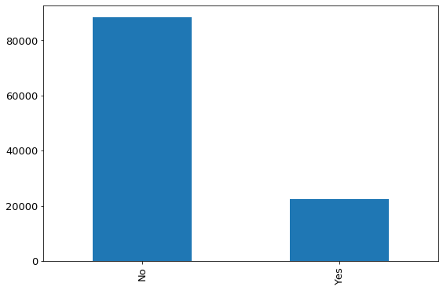

```python
brazil_df_clean['no-show'].value_counts().plot(kind='bar');
```

- The target variable is very imbalanced. There are a lot of observations of people that turned up than don't turned up.

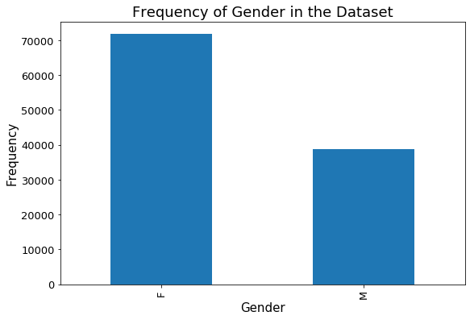

```python
brazil_df_clean.gender.value_counts().plot(kind='bar')
plt.xlabel('Gender')
plt.ylabel('Frequency')
plt.title('Frequency of Gender in the Dataset');
```

- There are more female gender in this dataset than male gender. Female is the greater proportion, woman takes way more care of they health in comparison to man.

### Research Question 1: What are the age groups patients who have most turned up?

- People in the age group of 50-60 are the most to turn up in frequency, followed by 30-40 and 40-50 groups.
- The relative proportion of each age group suggests that each group has a similar proportion of people who turned up and not turned up. The age group of 60-70 have more patients that turned up, on the other hand, the age group of 10-20 have more patients that have not turned up.

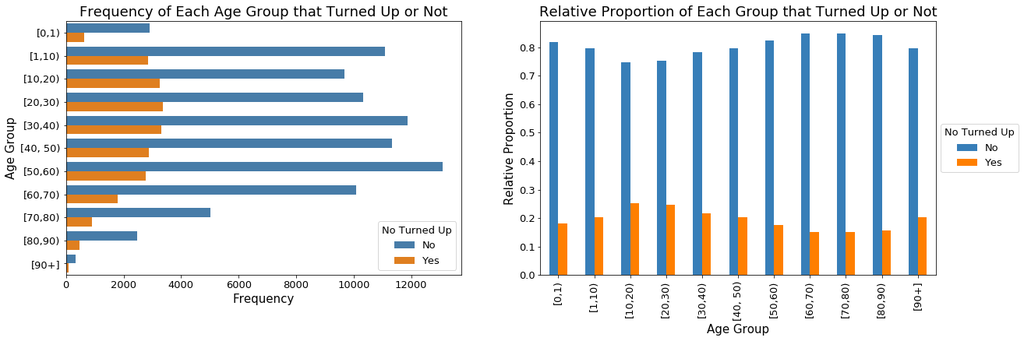

```python
palettes = ['#377eb8','#ff7f00']

fig = plt.figure(figsize=(20, 6))

ax1 = fig.add_subplot(1,2,1)
sb.countplot(data=brazil_df_clean, y='age_group', hue='no-show', palette=palettes, axes=ax1);
plt.xlabel('Frequency')
plt.ylabel('Age Group')
plt.legend(title='No Turned Up')
plt.title('Frequency of Each Age Group that Turned Up or Not')

# Thanks to https://stackoverflow.com/a/23377232
ax2 = fig.add_subplot(1,2,2)
df_ = brazil_df_clean.groupby(['age_group', 'no-show']).size()
prop_relative = df_.groupby(level=0).apply(lambda x:x / float(x.sum()))
prop_relative.unstack().plot(kind='bar', ax=ax2, color=palettes)
plt.legend(title='No Turned Up',loc='center left', bbox_to_anchor=(1, 0.5))
plt.xlabel('Age Group')
plt.ylabel('Relative Proportion')
plt.title('Relative Proportion of Each Group that Turned Up or Not');
```

### Research Question 2: People who have some disease/disability usually turned up?

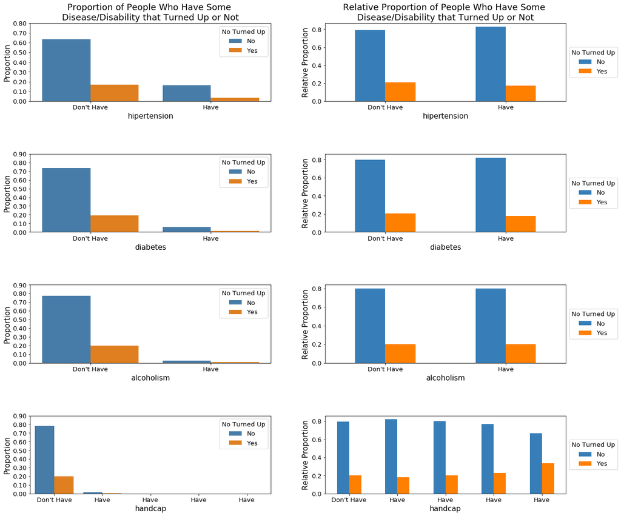

```python
cols = ['hipertension', 'diabetes', 'alcoholism', 'handcap']
n_points = brazil_df_clean.shape[0]

fig = plt.figure(figsize=(18, 15))
j = 0

for col in range(8):

    if col%2 == 0:
        max_count = brazil_df_clean[cols[j]].value_counts().max()
        max_prop = max_count / n_points

        tick_props = np.arange(0, max_prop, 0.10)
        tick_names = ['{:0.2f}'.format(v) for v in tick_props]

        ax1 = fig.add_subplot(4,2, col+1)
        sb.countplot(data=brazil_df_clean, x=cols[j], hue='no-show', palette=palettes, axes=ax1)
        plt.yticks(tick_props * n_points, tick_names)
        plt.legend(title='No Turned Up')
        plt.ylabel('Proportion')

        if col > 5:
            plt.xticks([0,1,2,3,4], ["Don't Have", "Have", "Have", "Have", "Have"])
        else:
            plt.xticks([0,1], ["Don't Have", "Have"])


        if col == 0:
            ax1.set_title('Proportion of People Who Have Some \nDisease/Disability that Turned Up or Not')

    else:
        ax2 = fig.add_subplot(4,2,col+1)
        df_ = brazil_df_clean.groupby([cols[j], 'no-show']).size()
        prop_relative = df_.groupby(level=0).apply(lambda x:x / float(x.sum()))
        prop_relative.unstack().plot(kind='bar', ax=ax2, color=palettes)
        plt.legend(title='No Turned Up',loc='center left', bbox_to_anchor=(1, 0.5))
        plt.ylabel('Relative Proportion')
        j += 1

        if col > 5:
            plt.xticks([0,1,2,3,4], ["Don't Have", "Have", "Have", "Have", "Have"], rotation=0)
        else:
            plt.xticks([0,1], ["Don't Have", "Have"], rotation=0)

        if col == 1:
            ax2.set_title('Relative Proportion of People Who Have Some \nDisease/Disability that Turned Up or Not')


fig.tight_layout(h_pad=5, w_pad=5)
```

### Research Question 3: The Scholarship (Bolsa Família) for each gender contributed to turned up?

- The resulsts suggests the patients who have *Bolsa Família* tends to not turned up in both genders.

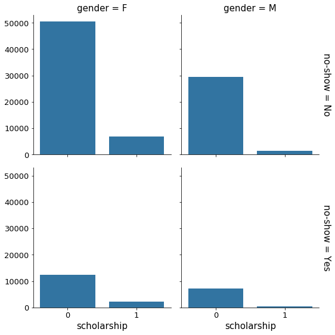

```python
g = sb.FacetGrid(data = brazil_df_clean, col = 'gender', row = 'no-show', size = 4,
                margin_titles = True)
g.map(sb.countplot, 'scholarship')
```

### Research Question 4: What is the impact of the location for the patients to turned up?

- From the frequency it looks like the ratio of Show to NoShow is almost the same for all Neighbourhood's.
- From the relative proportion, suggests the Neighbourhoods have around 80% Turned Up Rate. Except the location 'Ilhas Oceânicas de Trindade', that don't have any turned up observation.

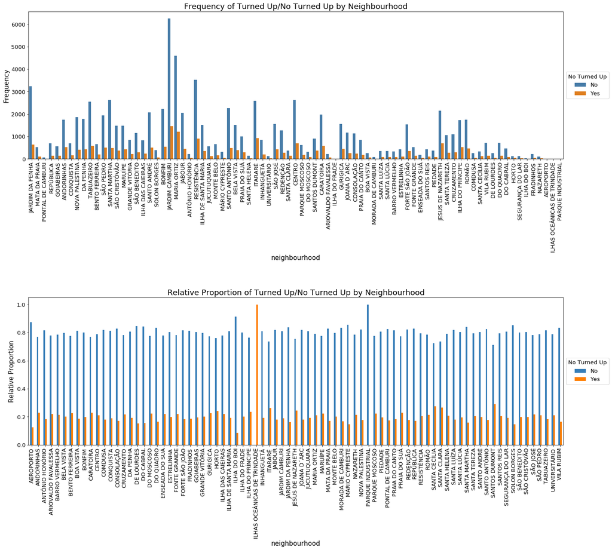

```python
fig = plt.figure(figsize=(20, 18))

ax1 = fig.add_subplot(2,1,1)
sb.countplot(data=brazil_df_clean, x='neighbourhood', hue='no-show', palette=palettes, axes=ax1);
plt.ylabel('Frequency')
plt.legend(title='No Turned Up',loc='center left', bbox_to_anchor=(1, 0.5))
plt.xticks(rotation=90)
plt.title('Frequency of Turned Up/No Turned Up by Neighbourhood')

ax2 = fig.add_subplot(2,1,2)
df_ = brazil_df_clean.groupby(['neighbourhood', 'no-show']).size()
prop_relative = df_.groupby(level=0).apply(lambda x:x / float(x.sum()))
prop_relative.unstack().plot(kind='bar', ax=ax2, color=palettes)
plt.legend(title='No Turned Up',loc='center left', bbox_to_anchor=(1, 0.5))
plt.xlabel('neighbourhood')
plt.ylabel('Relative Proportion')
plt.title('Relative Proportion of Turned Up/No Turned Up by Neighbourhood')

fig.tight_layout(h_pad=5, w_pad=5);
```